# Importing the Libraries

##### Contract

```
Month-to-month    3875
Two year          1685
One year          1472
Name: Contract, dtype: int64
```

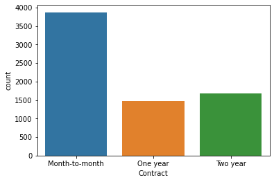

```python
## Checking the distribution of contract

print(df.Contract.value_counts())
sns.countplot(x = df.Contract);
```

```
Churn for subscribers with Month to Month contract
 No     2220
Yes    1655
Name: Churn, dtype: int64

Churn for subscribers with One Year contract
 No     1306
Yes     166
Name: Churn, dtype: int64

Churn for subscribers with Two Year contract
 No     1637
Yes      48
Name: Churn, dtype: int64
```

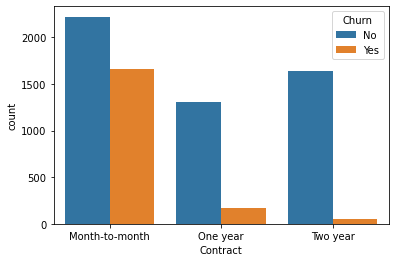

```python
## Checking the distribution of Contract with respect to churn

print("Churn for subscribers with Month to Month contract",'\n', df[df.Contract=='Month-to-month'].Churn.value_counts(),'\n')
print("Churn for subscribers with One Year contract",'\n',df[df.Contract=='One year'].Churn.value_counts(),'\n')
print("Churn for subscribers with Two Year contract",'\n',df[df.Contract=='Two year'].Churn.value_counts())
sns.countplot(x = df.Contract, hue = df.Churn);
```

```python
## Comparing Total Churn to Churn amongst subscribers with different contracts

print('Percentage Churn for subscribers',round(100*df.Churn.value_counts(1)[1],2),'percent')
print('Percentage Churn for subscribers with Month to Month contract',round(100*df[df.Contract == 'Month-to-month'].Churn.value_counts(1)[1],2),'percent')
print('Percentage Churn for subscribers with One Year contract',round(100* df[df.Contract == 'One year'].Churn.value_counts(1)[1],2),'percent')
print('Percentage Churn for subscribers with Two Year contract',round(100* df[df.Contract == 'Two year'].Churn.value_counts(1)[1],2),'percent')
```

```
Percentage Churn for subscribers 26.58 percent
Percentage Churn for subscribers with Month to Month contract 42.71 percent
Percentage Churn for subscribers with One Year contract 11.28 percent
Percentage Churn for subscribers with Two Year contract 2.85 percent
```

```python
## Testing the hypothesis that Churn is independent of Contract with chi-square test
## Null Hypothesis is that Churn is independent of Contract

chisquare([42.71,11.28,2.85], f_exp = [26.58,26.58,26.58])
```

```
Power_divergenceResult(statistic=39.781030850263356, pvalue=2.2996349933892153e-09)
```

##### Since p value < 0.05 we reject the null hypothesis. We see that the subscribers with month to month contracts are more likely to churn

##### Paperless Billing

```
Yes    4168
No     2864
Name: PaperlessBilling, dtype: int64
```

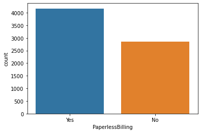

```python
## Checking the distribution of Paperless billing

print(df.PaperlessBilling.value_counts())
sns.countplot(x = df.PaperlessBilling);
```

```
Churn for subscribers with Paperless Billing
 No     2768
Yes    1400
Name: Churn, dtype: int64

Churn for subscribers without Paperless Billing
 No     2395
Yes     469
Name: Churn, dtype: int64
```

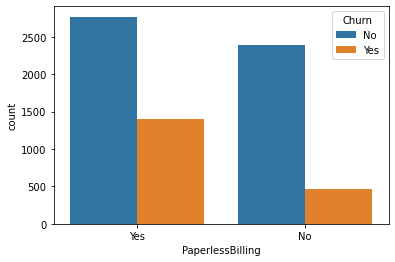

```python
## Checking the distribution of Paperless billing with respect to churn

print("Churn for subscribers with Paperless Billing",'\n', df[df.PaperlessBilling=='Yes'].Churn.value_counts(),'\n')
print("Churn for subscribers without Paperless Billing",'\n',df[df.PaperlessBilling=='No'].Churn.value_counts(),'\n')
sns.countplot(x = df.PaperlessBilling, hue = df.Churn);
```

```python
## Comparing Total Churn to Churn amongst subscribers with paperless billing and without paperless billing

print('Percentage Churn for subscribers',round(100*df.Churn.value_counts(1)[1],2),'percent')
print('Percentage Churn for subscribers with paperless billing',round(100*df[df.PaperlessBilling == 'Yes'].Churn.value_counts(1)[1],2),'percent')
print('Percentage Churn for subscribers without paperless billing',round(100* df[df.PaperlessBilling == 'No'].Churn.value_counts(1)[1],2),'percent')
```

```
Percentage Churn for subscribers 26.58 percent
Percentage Churn for subscribers with paperless billing 33.59 percent
Percentage Churn for subscribers without paperless billing 16.38 percent
```

```python
## Testing the hypothesis that Churn is independent of whether a subscriber has paperless billing or not with chi-square test
## Null Hypothesis is that Churn is independent of paperless billing

chisquare([33.59,16.38], f_exp = [26.58,26.58])
```

```
Power_divergenceResult(statistic=5.7629834462001535, pvalue=0.016367257504536575)
```

##### Since p value < 0.05 we reject the Null Hypothesis. We see that subscribers with paperless billing are more likely to churn

##### Payment Method

```
Electronic check             2365
Mailed check                 1604
Bank transfer (automatic)    1542
Credit card (automatic)      1521
Name: PaymentMethod, dtype: int64
```

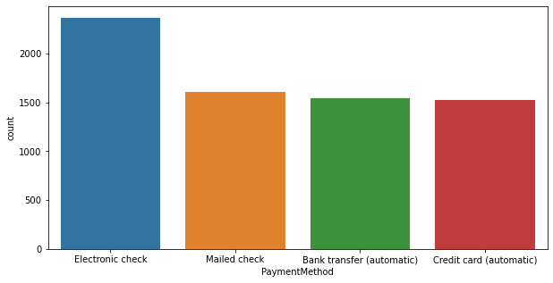

```python
## Checking the distribution of Payment Method

print(df.PaymentMethod.value_counts())
sns.countplot(x = df.PaymentMethod, ax = plt.subplots(figsize=(10,5))[1]);
```

```
Churn for subscribers with Electronic Check
 No     1294
Yes    1071
Name: Churn, dtype: int64

Churn for subscribers with Mailed Check
 No     1296
Yes     308
Name: Churn, dtype: int64

Churn for subscribers with Bank Transfer (automatic)
 No     1284
Yes     258
Name: Churn, dtype: int64

Churn for subscribers with Credit Card (automatic)
 No     1289
Yes     232
Name: Churn, dtype: int64
```

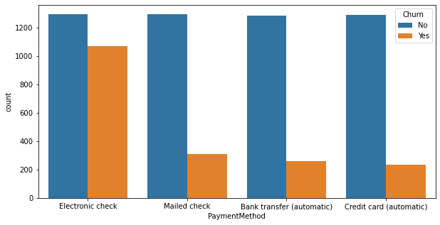

```python
## Checking the distribution of Payment Method with respect to churn

print("Churn for subscribers with Electronic Check",'\n', df[df.PaymentMethod=='Electronic check'].Churn.value_counts(),'\n')
print("Churn for subscribers with Mailed Check",'\n', df[df.PaymentMethod=='Mailed check'].Churn.value_counts(),'\n')
print("Churn for subscribers with Bank Transfer (automatic)",'\n', df[df.PaymentMethod=='Bank transfer (automatic)'].Churn.value_counts(),'\n')
print("Churn for subscribers with Credit Card (automatic)",'\n',df[df.PaymentMethod=='Credit card (automatic)'].Churn.value_counts(),'\n')
sns.countplot(x = df.PaymentMethod, hue = df.Churn, ax = plt.subplots(figsize=(10,5))[1]);
```

```python
## Comparing Total Churn to Churn amongst subscribers with different payment methods

print('Percentage Churn for subscribers',round(100*df.Churn.value_counts(1)[1],2),'percent')
print('Percentage Churn for subscribers with Electronic Check',round(100*df[df.PaymentMethod == 'Electronic check'].Churn.value_counts(1)[1],2),'percent')
print('Percentage Churn for subscribers without Mailed Check',round(100* df[df.PaymentMethod == 'Mailed check'].Churn.value_counts(1)[1],2),'percent')
print('Percentage Churn for subscribers without Bank transfer',round(100* df[df.PaymentMethod == 'Bank transfer (automatic)'].Churn.value_counts(1)[1],2),'percent')
print('Percentage Churn for subscribers without Credit Card',round(100* df[df.PaymentMethod == 'Credit card (automatic)'].Churn.value_counts(1)[1],2),'percent')
```

```
Percentage Churn for subscribers 26.58 percent
Percentage Churn for subscribers with Electronic Check 45.29 percent
Percentage Churn for subscribers without Mailed Check 19.2 percent
Percentage Churn for subscribers without Bank transfer 16.73 percent
Percentage Churn for subscribers without Credit Card 15.25 percent
```

```python
## Testing the hypothesis that Churn is independent of payment method with chi-square test
## Null Hypothesis is that Churn is independent of payment method

chisquare([45.29,19.2, 16.73, 15.25], f_exp = [26.58,26.58,26.58,26.58])
```

```
Power_divergenceResult(statistic=23.699018058690744, pvalue=2.8867830485905018e-05)
```

##### Since p value < 0.05 we reject the Null Hypothesis. We see that subscribers with payment method as electronic check are more likely to churn

##### Monthly Charges

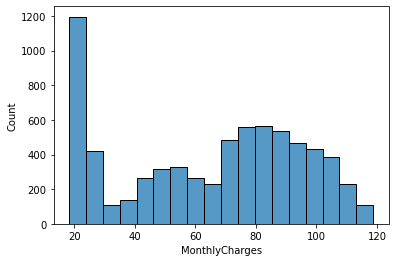

```python
## Checking the distribution of Monthly charges

sns.histplot(x = df.MonthlyCharges);
```

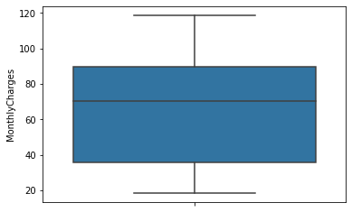

```python
## Boxplot

sns.boxplot(y = df.MonthlyCharges);
```

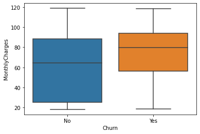

```python
## Checking Monthly charges of people who churned vs people who did not churn

sns.boxplot(x = df.Churn, y = df.MonthlyCharges)
```

##### We see that the on an average monthly charges for those subscribers who churned was higher than those who didn't

##### we can further test this using ANOVA

```python
## NULL Hypothesis is that the average monthly charges for people who churn and those who do not is same (difference is not statistically significant)

mod = ols('MonthlyCharges ~ Churn', data = df).fit()
aov_table = sm.stats.anova_lm(mod, typ = 2)
print(aov_table)
```

```
                sum_sq      df          F        PR(>F)
Churn     2.367127e+05     1.0  271.57699  6.760843e-60
Residual  6.127508e+06  7030.0        NaN           NaN
```

##### Since p value is < 0.05 we reject the Null Hypothesis. We see that people who churned on an average had higher monthly charges

##### Total Charges

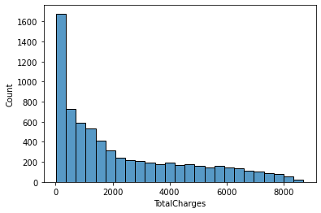

```python
## Checking the distribution of Total charges

sns.histplot(x = df.TotalCharges);
```

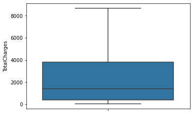

```python
## Boxplot

sns.boxplot(y = df.TotalCharges);
```

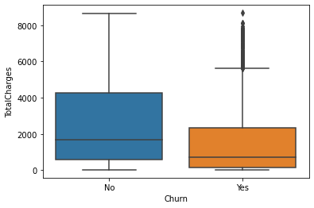

```python
## Checking distribution of Total Charges for subscribers who churned and who didn't

sns.boxplot(x = df.Churn, y = df.TotalCharges);
```

##### We see that the on an average total charges for those subscribers who churned was lower than those who didn't

##### we can further test this using ANOVA

```python
## NULL Hypothesis is that the average tenure for people who churn and those who do not is same (difference is not statistically significant)

mod = ols('TotalCharges ~ Churn', data = df).fit()
aov_table = sm.stats.anova_lm(mod, typ = 2)
print(aov_table)
```

```
                sum_sq      df           F        PR(>F)
Churn     1.437636e+09     1.0  291.344862  4.876866e-64
Residual  3.468942e+10  7030.0         NaN           NaN
```

##### Since p value is < 0.05 we reject the Null Hypothesis. We see that people who churned on an average had lower total charges

# Data Preprocessing

```python
## Replacing Categorical columns with Numeric Data

replacedict = {
                "MultipleLines":     {"No phone service": 1, "No": 2 ,"Yes": 3},
                "InternetService":   {"No": 1, "DSL": 2, "Fiber optic": 3},
                "OnlineSecurity":    {"No internet service": 1, "No": 2, "Yes": 3},
                "OnlineBackup":      {"No internet service": 1, "No": 2, "Yes": 3},
                "DeviceProtection":  {"No internet service": 1, "No": 2, "Yes": 3},
                "TechSupport":       {"No internet service": 1, "No": 2, "Yes": 3},
                "StreamingTV":       {"No internet service": 1, "No": 2, "Yes": 3},
                "StreamingMovies":   {"No internet service": 1, "No": 2, "Yes": 3},
                "Contract":          {"Month-to-month": 1, "One year": 2, "Two year": 3},
                "Churn":             {"No": 0, "Yes": 1 }
                }
oneHotCols=["gender", "SeniorCitizen", "Partner", "Dependents", "PhoneService", "PaperlessBilling", "PaymentMethod",]
```

```python
df = df.replace(replacedict)
df = pd.get_dummies(df,columns = oneHotCols)
df.head(15)
```

|  | tenure | MultipleLines | InternetService | OnlineSecurity | OnlineBackup | DeviceProtection | TechSupport | StreamingTV | StreamingMovies | Contract | ... | Dependents_No | Dependents_Yes | PhoneService_No | PhoneService_Yes | PaperlessBilling_No | PaperlessBilling_Yes | PaymentMethod_Bank transfer (automatic) | PaymentMethod_Credit card (automatic) | PaymentMethod_Electronic check | PaymentMethod_Mailed check |
| --- | --- | --- | --- | --- | --- | --- | --- | --- | --- | --- | --- | --- | --- | --- | --- | --- | --- | --- | --- | --- | --- |
| 0 | 1 | 1 | 2 | 2 | 3 | 2 | 2 | 2 | 2 | 1 | ... | 1 | 0 | 1 | 0 | 0 | 1 | 0 | 0 | 1 | 0 |
| 1 | 34 | 2 | 2 | 3 | 2 | 3 | 2 | 2 | 2 | 2 | ... | 1 | 0 | 0 | 1 | 1 | 0 | 0 | 0 | 0 | 1 |
| 2 | 2 | 2 | 2 | 3 | 3 | 2 | 2 | 2 | 2 | 1 | ... | 1 | 0 | 0 | 1 | 0 | 1 | 0 | 0 | 0 | 1 |
| 3 | 45 | 1 | 2 | 3 | 2 | 3 | 3 | 2 | 2 | 2 | ... | 1 | 0 | 1 | 0 | 1 | 0 | 1 | 0 | 0 | 0 |
| 4 | 2 | 2 | 3 | 2 | 2 | 2 | 2 | 2 | 2 | 1 | ... | 1 | 0 | 0 | 1 | 0 | 1 | 0 | 0 | 1 | 0 |
| 5 | 8 | 3 | 3 | 2 | 2 | 3 | 2 | 3 | 3 | 1 | ... | 1 | 0 | 0 | 1 | 0 | 1 | 0 | 0 | 1 | 0 |
| 6 | 22 | 3 | 3 | 2 | 3 | 2 | 2 | 3 | 2 | 1 | ... | 0 | 1 | 0 | 1 | 0 | 1 | 0 | 1 | 0 | 0 |
| 7 | 10 | 1 | 2 | 3 | 2 | 2 | 2 | 2 | 2 | 1 | ... | 1 | 0 | 1 | 0 | 1 | 0 | 0 | 0 | 0 | 1 |
| 8 | 28 | 3 | 3 | 2 | 2 | 3 | 3 | 3 | 3 | 1 | ... | 1 | 0 | 0 | 1 | 0 | 1 | 0 | 0 | 1 | 0 |
| 9 | 62 | 2 | 2 | 3 | 3 | 2 | 2 | 2 | 2 | 2 | ... | 0 | 1 | 0 | 1 | 1 | 0 | 1 | 0 | 0 | 0 |
| 10 | 13 | 2 | 2 | 3 | 2 | 2 | 2 | 2 | 2 | 1 | ... | 0 | 1 | 0 | 1 | 0 | 1 | 0 | 0 | 0 | 1 |
| 11 | 16 | 2 | 1 | 1 | 1 | 1 | 1 | 1 | 1 | 3 | ... | 1 | 0 | 0 | 1 | 1 | 0 | 0 | 1 | 0 | 0 |
| 12 | 58 | 3 | 3 | 2 | 2 | 3 | 2 | 3 | 3 | 2 | ... | 1 | 0 | 0 | 1 | 1 | 0 | 0 | 1 | 0 | 0 |
| 13 | 49 | 3 | 3 | 2 | 3 | 3 | 2 | 3 | 3 | 1 | ... | 1 | 0 | 0 | 1 | 0 | 1 | 1 | 0 | 0 | 0 |
| 14 | 25 | 2 | 3 | 3 | 2 | 3 | 3 | 3 | 3 | 1 | ... | 1 | 0 | 0 | 1 | 0 | 1 | 0 | 0 | 1 | 0 |

15 rows × 29 columns

```python
df.info()
```

```
<class 'pandas.core.frame.DataFrame'>
Int64Index: 7032 entries, 0 to 7042
Data columns (total 29 columns):
 #   Column                                   Non-Null Count  Dtype
---  ------                                   --------------  -----
 0   tenure                                   7032 non-null   int64
 1   MultipleLines                            7032 non-null   int64
 2   InternetService                          7032 non-null   int64
 3   OnlineSecurity                           7032 non-null   int64
 4   OnlineBackup                             7032 non-null   int64
 5   DeviceProtection                         7032 non-null   int64
 6   TechSupport                              7032 non-null   int64
 7   StreamingTV                              7032 non-null   int64
 8   StreamingMovies                          7032 non-null   int64
 9   Contract                                 7032 non-null   int64
```

[output cut: 21 more lines]

```python
## Removing redundant dummy variables:

df = df.drop(["gender_Male","SeniorCitizen_Yes","Partner_Yes","Dependents_Yes","PhoneService_Yes","PaperlessBilling_Yes","PaymentMethod_Mailed check"], axis = 1)
```

```python
df.info()
```

```
<class 'pandas.core.frame.DataFrame'>
Int64Index: 7032 entries, 0 to 7042
Data columns (total 22 columns):
 #   Column                                   Non-Null Count  Dtype
---  ------                                   --------------  -----
 0   tenure                                   7032 non-null   int64
 1   MultipleLines                            7032 non-null   int64
 2   InternetService                          7032 non-null   int64
 3   OnlineSecurity                           7032 non-null   int64
 4   OnlineBackup                             7032 non-null   int64
 5   DeviceProtection                         7032 non-null   int64
 6   TechSupport                              7032 non-null   int64
 7   StreamingTV                              7032 non-null   int64
 8   StreamingMovies                          7032 non-null   int64
 9   Contract                                 7032 non-null   int64
 10  MonthlyCharges                           7032 non-null   float64
 11  TotalCharges                             7032 non-null   float64
 12  Churn                                    7032 non-null   int64
 13  gender_Female                            7032 non-null   uint8
 14  SeniorCitizen_No                         7032 non-null   uint8
 15  Partner_No                               7032 non-null   uint8
 16  Dependents_No                            7032 non-null   uint8
 17  PhoneService_No                          7032 non-null   uint8
 18  PaperlessBilling_No                      7032 non-null   uint8
 19  PaymentMethod_Bank transfer (automatic)  7032 non-null   uint8
 20  PaymentMethod_Credit card (automatic)    7032 non-null   uint8
 21  PaymentMethod_Electronic check           7032 non-null   uint8
dtypes: float64(2), int64(11), uint8(9)
memory usage: 1.1 MB
```

```python
## Segregating Predictor variables from Taget Variable

X = df.drop('Churn',axis=1)
y = df['Churn']
```

```python
## Using SMOTE (Synthetic Minority Oversampling Technique) to oversample. If the results are not good we will then try undersampling of the majority class

## The decision to use over sampling was used after trying models without oversampling and getting accuracy less than 79%

## importing library
from imblearn.over_sampling import SMOTE

smote = SMOTE()

# fit predictor and target variable
X_new, y_new = smote.fit_resample(X, y)

print(y.value_counts())
print(y_new.value_counts())
```

```
0    5163
1    1869
Name: Churn, dtype: int64
0    5163
1    5163
Name: Churn, dtype: int64
```

```python
## Checking for Target balancing (percentage)

y_new.value_counts(1)
```

```
0    0.5
1    0.5
Name: Churn, dtype: float64
```

##### The data was a little imbalanced with 73.42% No and 26.58% Yes for Churn. However, to get better results we used SMOTE and performed target balancing.

```python
## Train-Test Split

X_train, X_test, y_train, y_test = train_test_split(X_new,y_new,test_size = 0.3, random_state=0)
```

```python
## Checking if train and test data have similar characterstics as original data

print(f'percentage of subscribers with churn = yes in original data set is {round(100*y.value_counts(1)[1],2)} percent')
print(f'percentage of subscribers with churn = yes in train set is {round(100*y_train.value_counts(1)[1],2)} percent')
print(f'percentage of subscribers with churn = yes in test set is {round(100*y_test.value_counts(1)[1],2)} percent')
```

```
percentage of subscribers with churn = yes in original data set is 26.58 percent
percentage of subscribers with churn = yes in train set is 49.9 percent
percentage of subscribers with churn = yes in test set is 50.23 percent
```

# Model Training Testing and Tuning

##### Random Forest

```python
model_RF = RandomForestClassifier(random_state=42)
```

```python
model_RF.fit(X_train,y_train)
```

```
RandomForestClassifier(random_state=42)
```

```python
RF_test_score = model_RF.score(X_test,y_test)
```

```python
RF_train_score = model_RF.score(X_train,y_train)
```

```python
RF_train_score,RF_test_score
```

```
(0.9984781405644715, 0.8508715300193673)
```

##### Random Forest gives a decent result of 85.09% without any hyperparameter tuning, but looking at the Train results we can see there can be some amount of overfitting

##### Bagging Classifier - with Decision Tree base estimator

```python
model_bagging = BaggingClassifier(random_state=42)
```

```python
model_bagging.fit(X_train,y_train)
```

```
BaggingClassifier(random_state=42)
```

```python
BAG_test_score = model_bagging.score(X_test,y_test)
```

```python
BAG_train_score = model_bagging.score(X_train,y_train)
```

```python
BAG_train_score,BAG_test_score
```

```
(0.9865799667957942, 0.8321497740477728)
```

##### Bagging Classifier with decision tree as the base estimator gives a good result of 83.21% without any hyperparameter tuning, but it is not as good as Random Forest. Again we see some amount of overfitting in this case as well

##### Bagging Classifier - with SVC base estimator

```python
from sklearn.svm import SVC
```

```python
model_bagging_SVC = BaggingClassifier(base_estimator=SVC(), n_estimators=10, random_state=42)
```

```python
model_bagging_SVC.fit(X_train,y_train)
```

```
BaggingClassifier(base_estimator=SVC(), random_state=42)
```

```python
BAG_SVC_test_score = model_bagging_SVC.score(X_test,y_test)
```

```python
BAG_SVC_train_score = model_bagging_SVC.score(X_train,y_train)
```

```python
BAG_SVC_train_score, BAG_SVC_test_score
```

```
(0.6514941892639734, 0.657520981278244)
```

##### Bagging Classifier with Support Vector Classifier as the base estimator gives a poor accuracy of 65.75%, We see the train accuracy is even worse

##### AdaBoost

```python
model_adaboost = AdaBoostClassifier(random_state=42)
```

```python
model_adaboost.fit(X_train,y_train)
```

```
AdaBoostClassifier(random_state=42)
```

```python
ADA_test_score = model_adaboost.score(X_test,y_test)
```

```python
ADA_train_score = model_adaboost.score(X_train,y_train)
```

```python
ADA_train_score, ADA_test_score
```

```
(0.8281682346430548, 0.841187863137508)
```

##### The Adaboost model also gives a good accuracy of 84.12% without hyperparameter tuning. This test accuracy is even better than the train accuracy

##### Gradient Boosting

```python
model_gradboost = GradientBoostingClassifier(random_state=42)
```

```python
model_gradboost.fit(X_train,y_train)
```

```
GradientBoostingClassifier(random_state=42)
```

```python
GRAD_test_score = model_gradboost.score(X_test,y_test)
```

```python
GRAD_train_score = model_gradboost.score(X_train,y_train)
```

```python
GRAD_train_score, GRAD_test_score
```

```
(0.847399003873824, 0.8457069076823758)
```

##### The Gradient Boosting Model also gives a good accuracy of 84.57% without Hyperparameter tuning. The train accuracy is also quite close to the test accuracy

##### XGBoost

```python
model_xgb = XGBClassifier(random_state = 42)
```

```python
model_xgb.fit(X_train,y_train)
```

```
[23:04:30] WARNING: C:/Users/Administrator/workspace/xgboost-win64_release_1.4.0/src/learner.cc:1095: Starting in XGBoost 1.3.0, the default evaluation metric used with the objective 'binary:logistic' was changed from 'error' to 'logloss'. Explicitly set eval_metric if you'd like to restore the old …
```

```
XGBClassifier(base_score=0.5, booster='gbtree', colsample_bylevel=1,
              colsample_bynode=1, colsample_bytree=1, gamma=0, gpu_id=-1,
              importance_type='gain', interaction_constraints='',
              learning_rate=0.300000012, max_delta_step=0, max_depth=6,
              min_child_weight=1, missing=nan, monotone_constraints='()',
              n_estimators=100, n_jobs=8, num_parallel_tree=1, random_state=42,
              reg_alpha=0, reg_lambda=1, scale_pos_weight=1, subsample=1,
              tree_method='exact', validate_parameters=1, verbosity=None)
```

```python
XGB_test_score = model_xgb.score(X_test,y_test)
```

```python
XGB_train_score = model_xgb.score(X_train,y_train)
```

```python
XGB_train_score, XGB_test_score
```

```
(0.956972883231876, 0.8502259522272434)
```

##### Since the best two models are RF and XGBoost we can try Hyperparameter Tuning for both and see if results improve further. We could also look at Gradient Boosting since it also gave good results, However, XGBoost is an enhancement on gradient boosting so we will look at only XGBoost for Hyperparameter tuning

##### Random Forest with Hyperparameter tuning with Randomized Search CV

```python
## Creating the paramater grid for RandomizedSearch CV for Random Forest

from sklearn.model_selection import RandomizedSearchCV



# Number of trees in random forest
n_estimators = [int(x) for x in np.linspace(start = 200, stop = 2000, num = 19)]

# Number of features to consider at every split
max_features = ['auto', 'sqrt']

# Maximum number of levels in tree
max_depth = [int(x) for x in np.linspace(10, 100, num = 10)]
max_depth.append(None)

# Minimum number of samples required to split a node
min_samples_split = [2, 5, 10]

# Minimum number of samples required at each leaf node
min_samples_leaf = [1, 2, 4]

# Method of selecting samples for training each tree
bootstrap = [True, False]

# Create the random grid
random_grid = {'n_estimators': n_estimators,
               'max_features': max_features,
               'max_depth': max_depth,
               'min_samples_split': min_samples_split,
               'min_samples_leaf': min_samples_leaf,
               'bootstrap': bootstrap}
print(random_grid)
```

```
{'n_estimators': [200, 300, 400, 500, 600, 700, 800, 900, 1000, 1100, 1200, 1300, 1400, 1500, 1600, 1700, 1800, 1900, 2000], 'max_features': ['auto', 'sqrt'], 'max_depth': [10, 20, 30, 40, 50, 60, 70, 80, 90, 100, None], 'min_samples_split': [2, 5, 10], 'min_samples_leaf': [1, 2, 4], 'bootstrap': [T…
```

```python
# Use the random grid to search for best hyperparameters

rf = RandomForestClassifier()  ## Base Model

# Random search of parameters, using 3 fold cross validation. We could have higher number for cross validation. But it would be extremely compute intensive
# search across 100 different combinations, and use all available cores

rf_random = RandomizedSearchCV(estimator = rf, param_distributions = random_grid, n_iter = 100, cv = 3, verbose=2, random_state=1, n_jobs = -1)

# Fit the random search model

rf_random.fit(X_train, y_train)
```

```
Fitting 3 folds for each of 100 candidates, totalling 300 fits
```

```
RandomizedSearchCV(cv=3, estimator=RandomForestClassifier(), n_iter=100,
                   n_jobs=-1,
                   param_distributions={'bootstrap': [True, False],
                                        'max_depth': [10, 20, 30, 40, 50, 60,
                                                      70, 80, 90, 100, None],
                                        'max_features': ['auto', 'sqrt'],
                                        'min_samples_leaf': [1, 2, 4],
                                        'min_samples_split': [2, 5, 10],
                                        'n_estimators': [200, 300, 400, 500,
                                                         600, 700, 800, 900,
                                                         1000, 1100, 1200, 1300,
                                                         1400, 1500, 1600, 1700,
                                                         1800, 1900, 2000]},
                   random_state=1, verbose=2)
```

```python
rf_random.best_params_ ## Best Parameters for RF model
```

```
{'n_estimators': 1600,
 'min_samples_split': 5,
 'min_samples_leaf': 2,
 'max_features': 'sqrt',
 'max_depth': 20,
 'bootstrap': False}
```

```python
RF_Random_test_score = rf_random.score(X_test,y_test)
```

```python
RF_Random_train_score = rf_random.score(X_train,y_train)
```

```python
RF_Random_train_score, RF_Random_test_score
```

```
(0.9856115107913669, 0.8511943189154293)
```

##### While there is a very slight improvement in test scores with Hyperparameter tuning, we see that the train score is quite high indicating some amount of over-fitting. Moreover, This Hyperparameter tuning is extremely compute intensive and is not worth the extra time and compute energy when compared with the improved accuracy

```python
## Predicting the target variable in the test set with the best Random Forest Model

y_rfr_pred = rf_random.predict(X_test)
```

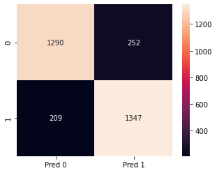

```python
## Drawing up the confusion matrix for the best Random Forest Model

lab = [0, 1]
plab = ['Pred 0', 'Pred 1']
cm = confusion_matrix(y_test,y_rfr_pred,labels = lab)

df_cm = pd.DataFrame(cm, index = [i for i in lab], columns = [i for i in plab])
plt.figure(figsize = (5,4))
sns.heatmap(df_cm ,annot=True, fmt = 'g');
```

```python
## Printing the classification report for the best Random Forest Model

print(classification_report(y_test,y_rfr_pred))
```

```
              precision    recall  f1-score   support

           0       0.86      0.84      0.85      1542
           1       0.84      0.87      0.85      1556

    accuracy                           0.85      3098
   macro avg       0.85      0.85      0.85      3098
weighted avg       0.85      0.85      0.85      3098
```

##### XGBoost with Hyperparameter tuning with Randomized Search CV

```python
## Creating the paramater grid for RandomizedSearch CV for XGBoost

params_xgb = {
    "colsample_bytree": [round(x,2) for x in np.linspace(.1,1,num=10)],
    "gamma": [round(x,2) for x in np.linspace(.1,0.5,num=5)],
    "learning_rate": [round(x,2) for x in np.linspace(0.03,0.3,num=10)], # default 0.1
    "max_depth": [int(x) for x in np.linspace(start = 2, stop = 6, num = 5)], # default 3
    "n_estimators": [int(x) for x in np.linspace(start = 200, stop = 2000, num = 19)], # default 100
    "subsample": [x for x in np.linspace(.5,1,num=6)]
}
```

```python
## Creating the base model first and then using the parameter grid for randomized search

model_xgb2 = XGBClassifier(base_score=0.5, booster='gbtree', colsample_bylevel=1,
              colsample_bynode=1, gpu_id=-1,
              importance_type='gain', interaction_constraints='',
              max_delta_step=0,
              min_child_weight=1, monotone_constraints='()',
              n_jobs=8, num_parallel_tree=1, random_state=42,
              reg_alpha=0, reg_lambda=1, scale_pos_weight=1,
              tree_method='exact', validate_parameters=1, verbosity=None)

XGB_random = RandomizedSearchCV(estimator = model_xgb2, param_distributions = params_xgb, n_iter = 100, cv = 3, verbose=2, random_state=42, n_jobs = -1)

XGB_random.fit(X_train,y_train)
```

```
Fitting 3 folds for each of 100 candidates, totalling 300 fits
[23:27:10] WARNING: C:/Users/Administrator/workspace/xgboost-win64_release_1.4.0/src/learner.cc:1095: Starting in XGBoost 1.3.0, the default evaluation metric used with the objective 'binary:logistic' was changed from 'error' to 'logloss'. Explicitly set eval_metric if you'd like to restore the old …
```

```
RandomizedSearchCV(cv=3,
                   estimator=XGBClassifier(base_score=0.5, booster='gbtree',
                                           colsample_bylevel=1,
                                           colsample_bynode=1,
                                           colsample_bytree=None, gamma=None,
                                           gpu_id=-1, importance_type='gain',
                                           interaction_constraints='',
                                           learning_rate=None, max_delta_step=0,
                                           max_depth=None, min_child_weight=1,
                                           missing=nan,
                                           monotone_constraints='()',
                                           n_estimators=100, n_jobs=8,
                                           num_...
                   param_distributions={'colsample_bytree': [0.1, 0.2, 0.3, 0.4,
                                                             0.5, 0.6, 0.7, 0.8,
                                                             0.9, 1.0],
                                        'gamma': [0.1, 0.2, 0.3, 0.4, 0.5],
                                        'learning_rate': [0.03, 0.06, 0.09,
                                                          0.12, 0.15, 0.18,
                                                          0.21, 0.24, 0.27,
                                                          0.3],
                                        'max_depth': [2, 3, 4, 5, 6],
                                        'n_estimators': [200, 300, 400, 500,
                                                         600, 700, 800, 900,
                                                         1000, 1100, 1200, 1300,
                                                         1400, 1500, 1600, 1700,
                                                         1800, 1900, 2000],
                                        'subsample': [0.5, 0.6, 0.7, 0.8, 0.9,
                                                      1.0]},
                   random_state=42, verbose=2)
```

```python
XGB_random_test_score = XGB_random.score(X_test,y_test)
```

```python
XGB_random_train_score = XGB_random.score(X_train,y_train)
```

```python
XGB_random_train_score, XGB_random_test_score
```

```
(0.9777255118981738, 0.8612007746933505)
```

```python
XGB_random.best_params_
```

```
{'subsample': 0.8,
 'n_estimators': 1400,
 'max_depth': 6,
 'learning_rate': 0.03,
 'gamma': 0.3,
 'colsample_bytree': 0.9}
```

##### While there is a slight improvement in test scores with Hyperparameter tuning of the XBoost model, we see that the train score is also high indicating some amount of over-fitting. Moreover, This Hyperparameter tuning is extremely compute intensive.

##### Overall we see the best XGBoost Model Performs slightly better than the best Random Forest Model

```python
## Predicting the target variable in the test set with the best XGBoost Model

y_xgb_pred = XGB_random.predict(X_test)
```

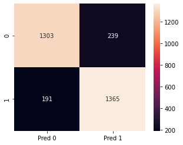

```python
## Drawing up the confusion matrix for the best XGBoost Model

lab = [0, 1]
plab = ['Pred 0', 'Pred 1']
cm = confusion_matrix(y_test,y_xgb_pred,labels = lab)

df_cm = pd.DataFrame(cm, index = [i for i in lab], columns = [i for i in plab])
plt.figure(figsize = (5,4))
sns.heatmap(df_cm ,annot=True, fmt = 'g');
```

```python
## Printing the classification report for the best XGBoost Model

print(classification_report(y_test,y_xgb_pred))
```

```
              precision    recall  f1-score   support

           0       0.87      0.85      0.86      1542
           1       0.85      0.88      0.86      1556

    accuracy                           0.86      3098
   macro avg       0.86      0.86      0.86      3098
weighted avg       0.86      0.86      0.86      3098
```

##### Using Stacking Ensemble with different Classifiers

```python
##Creating a set of level 0 classifiers followed by a random forest classifier as the final estimator

from sklearn.ensemble import StackingClassifier
from sklearn.linear_model import LogisticRegression
from sklearn.tree import DecisionTreeClassifier
from sklearn.neighbors import KNeighborsClassifier
from sklearn.naive_bayes import GaussianNB


level0 = list()
level0.append(('lr', LogisticRegression()))
level0.append(('knn', KNeighborsClassifier()))
level0.append(('cart', DecisionTreeClassifier()))
level0.append(('svm', SVC()))
level0.append(('bayes', GaussianNB()))
level0.append(('random_forest', RandomForestClassifier()))
level0.append(('Bagging', BaggingClassifier()))
level0.append(('Adboost', AdaBoostClassifier()))
level0.append(('gradient_boost', GradientBoostingClassifier()))
level0.append(('XGB', XGBClassifier()))

# define meta learner model
level1 = RandomForestClassifier(random_state=42)
# define the stacking ensemble
model_stack = StackingClassifier(estimators=level0, final_estimator=level1, cv=5)
# fit the model on all available data
model_stack.fit(X_train, y_train)
```

[output not shown]

```
StackingClassifier(cv=5,
                   estimators=[('lr', LogisticRegression()),
                               ('knn', KNeighborsClassifier()),
                               ('cart', DecisionTreeClassifier()),
                               ('svm', SVC()), ('bayes', GaussianNB()),
                               ('random_forest', RandomForestClassifier()),
                               ('Bagging', BaggingClassifier()),
                               ('Adboost', AdaBoostClassifier()),
                               ('gradient_boost', GradientBoostingClassifier()),
                               ('XGB',
                                XGBClassifier(base_sc...
                                              learning_rate=None,
                                              max_delta_step=None,
                                              max_depth=None,
                                              min_child_weight=None,
                                              missing=nan,
                                              monotone_constraints=None,
                                              n_estimators=100, n_jobs=None,
                                              num_parallel_tree=None,
                                              random_state=None, reg_alpha=None,
                                              reg_lambda=None,
                                              scale_pos_weight=None,
                                              subsample=None, tree_method=None,
                                              validate_parameters=None,
                                              verbosity=None))],
                   final_estimator=RandomForestClassifier(random_state=42))
```

```python
STACK_test_score = model_stack.score(X_test,y_test)
```

```python
STACK_train_score = model_stack.score(X_train,y_train)
```

```python
STACK_train_score, STACK_test_score
```

```
(0.9418926397343663, 0.8621691413815364)
```

##### We see that Stacking Ensemble method gives us results which are even better than the tuned Random Forest model and the overfitting also seems to be lesser than the previous two models of tuned Random Forest and XGBoost. However, the biggest advantage is that the stacking model is far less compute intensive than the tuned RF and XGB

```python
## Predicting the target variable in the test set with the Stacking Ensemble Model

y_stack_pred = model_stack.predict(X_test)
```

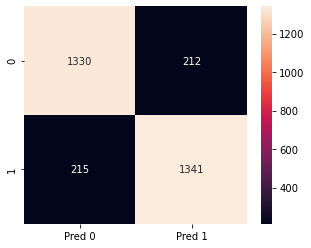

```python
## Drawing up the confusion matrix for the best Stacking Ensemble Model

lab = [0, 1]
plab = ['Pred 0', 'Pred 1']
cm = confusion_matrix(y_test,y_stack_pred,labels = lab)

df_cm = pd.DataFrame(cm, index = [i for i in lab], columns = [i for i in plab])
plt.figure(figsize = (5,4))
sns.heatmap(df_cm ,annot=True, fmt = 'g');
```

```python
## Printing the classification report for the Stacking Ensemble Model

print(classification_report(y_test,y_stack_pred))
```

```
              precision    recall  f1-score   support

           0       0.86      0.86      0.86      1542
           1       0.86      0.86      0.86      1556

    accuracy                           0.86      3098
   macro avg       0.86      0.86      0.86      3098
weighted avg       0.86      0.86      0.86      3098
```

##### Creating a Table/DataFrame with the different models tried with their train and test accuracies

```python
Accuracies_df = pd.DataFrame(columns = ['Model_Name','Train_set_Accuracy (%)','Test_set_Accuracy (%)'])
```

```python
Accuracies_df = Accuracies_df.append({
                      'Model_Name':         'Random Forest Classifier',
                      'Train_set_Accuracy (%)':  round(100*RF_train_score,2),
                      'Test_set_Accuracy (%)':   round(100*RF_test_score,2)
                      }, ignore_index=True)
```

```python
Accuracies_df = Accuracies_df.append({
                      'Model_Name':         'Bagging Classifier',
                      'Train_set_Accuracy (%)':  round(100*BAG_train_score,2),
                      'Test_set_Accuracy (%)':   round(100*BAG_test_score,2)
                      }, ignore_index=True)
```

```python
Accuracies_df = Accuracies_df.append({
                      'Model_Name':         'AdaBoost Classifier',
                      'Train_set_Accuracy (%)':  round(100*ADA_train_score,2),
                      'Test_set_Accuracy (%)':   round(100*ADA_test_score,2)
                      }, ignore_index=True)
```

```python
Accuracies_df = Accuracies_df.append({
                      'Model_Name':         'Gradient Boosting Classifier',
                      'Train_set_Accuracy (%)':  round(100*GRAD_train_score,2),
                      'Test_set_Accuracy (%)':   round(100*GRAD_test_score,2)
                      }, ignore_index=True)
```

```python
Accuracies_df = Accuracies_df.append({
                      'Model_Name':         'XGBoost Classifier',
                      'Train_set_Accuracy (%)':  round(100*XGB_train_score,2),
                      'Test_set_Accuracy (%)':   round(100*XGB_test_score,2)
                      }, ignore_index=True)
```

```python
Accuracies_df = Accuracies_df.append({
                      'Model_Name':         'Tuned RF Classifier',
                      'Train_set_Accuracy (%)':  round(100*RF_Random_train_score,2),
                      'Test_set_Accuracy (%)':   round(100*RF_Random_test_score,2)
                      }, ignore_index=True)
```

```python
Accuracies_df = Accuracies_df.append({
                      'Model_Name':         'Tuned XGBoost Classifier',
                      'Train_set_Accuracy (%)':  round(100*XGB_random_train_score,2),
                      'Test_set_Accuracy (%)':   round(100*XGB_random_test_score,2)
                      }, ignore_index=True)
```

```python
Accuracies_df = Accuracies_df.append({
                      'Model_Name':         'Stacking Ensemble Classifier',
                      'Train_set_Accuracy (%)':  round(100*STACK_train_score,2),
                      'Test_set_Accuracy (%)':   round(100*STACK_test_score,2)
                      }, ignore_index=True)
```

```python
Accuracies_df
```

|  | Model_Name | Train_set_Accuracy (%) | Test_set_Accuracy (%) |
| --- | --- | --- | --- |
| 0 | Random Forest Classifier | 99.85 | 85.09 |
| 1 | Bagging Classifier | 98.66 | 83.21 |
| 2 | AdaBoost Classifier | 82.82 | 84.12 |
| 3 | Gradient Boosting Classifier | 84.74 | 84.57 |
| 4 | XGBoost Classifier | 95.70 | 85.02 |
| 5 | Tuned RF Classifier | 98.56 | 85.12 |
| 6 | Tuned XGBoost Classifier | 97.77 | 86.12 |
| 7 | Stacking Ensemble Classifier | 94.19 | 86.22 |

### Now that we have selected a ensemble algorithm. We need to train the model on the entire data before saving it or creating a pickle file

```python
final_stack_model = StackingClassifier(estimators=level0, final_estimator=level1, cv=5)
final_stack_model.fit(X_new,y_new)
```

[output not shown]

```
StackingClassifier(cv=5,
                   estimators=[('lr', LogisticRegression()),
                               ('knn', KNeighborsClassifier()),
                               ('cart', DecisionTreeClassifier()),
                               ('svm', SVC()), ('bayes', GaussianNB()),
                               ('random_forest', RandomForestClassifier()),
                               ('Bagging', BaggingClassifier()),
                               ('Adboost', AdaBoostClassifier()),
                               ('gradient_boost', GradientBoostingClassifier()),
                               ('XGB',
                                XGBClassifier(base_sc...
                                              learning_rate=None,
                                              max_delta_step=None,
                                              max_depth=None,
                                              min_child_weight=None,
                                              missing=nan,
                                              monotone_constraints=None,
                                              n_estimators=100, n_jobs=None,
                                              num_parallel_tree=None,
                                              random_state=None, reg_alpha=None,
                                              reg_lambda=None,
                                              scale_pos_weight=None,
                                              subsample=None, tree_method=None,
                                              validate_parameters=None,
                                              verbosity=None))],
                   final_estimator=RandomForestClassifier(random_state=42))
```

### Pickling the model

```python
#import module

import pickle

pickle.dump(final_stack_model, open('final_ensemble_model.pkl','wb'))
```

```python
# Loading model to compare the results
# model = pickle.load(open('final_ensemble_model.pkl','rb'))
```

# Conclusion and Improvisation

##### In conclusion we can say that the Ensemble Techniques are quite powerful and especially the Random Forest , XGBoost and Stacking Ensemble Techniques.

I had built models like Logistic regression, Support Vector, Naive Bayes and KNN but none of them came close to the accuracy we got with the Ensemble Techniques.

However, an observation that I had was that the tuning of Ensemble Techniques is quite compute intensive and in terms of the value addition with respect to accuracy it is not as much. Therefore it is important to do a cost benefit analysis before hyperparameter tuning for Ensemble Techiniques.

Another observation was that even among ensemble techniques, Stacking can be very useful.

##### From a perspective of data collection the Telecom operator could:

1. Try and improve data quality in terms of missing data
2. Try and get more data, data for just 7043 subscribers is quite low for a telecom operator
3. Try and get more relevant features such as internet(data) usage, phone usage, Closed group networks, prepaid/postpaid etc.
4. There is no observation on Variety and Velocity of data as the data is just one kind - tabular and is static
5. There is no way to test the veracity of the data